# Homework Assignment 1

https://github.com/mkalmus/TO628-Fall-2020-Work

Michael Kalmus

Assigned: Oct 24, 2020, Due Sun Nov 01, 2020 11:59PM

## HW-1 Instructions

> Our class emphasizes clear communication of data analysis results to non-technical audiences. I expect your HTML output documents to be readable and well formatted. I expect you to put ample comments in your R code to make the code understandable. Along with accuracy of results, I am looking for quality of presentation as well. This homework is due by **11:59PM on Nov 01st**. To complete this assignment, follow these steps:
1. Create a new RStudio Project for this HW. Sync the project directory with a GitHub Repository (see instructions on Canvas on how to do that).
2. Download the `HW1.Rmd` file from Canvas. Save the file in the RStudio Project Directory.
3. Open `HW1.Rmd` in RStudio. Replace the “Your Name Here” text in the `author:` field with your name.
4. Supply your solutions to the homework by editing `HW1.Rmd`.
5. Run your code in the Console and Knit HTML frequently to check for errors.
6. You may find it easier to solve a problem by interacting only with the Console at first.
7. When you have completed the homework please check that your knits correctly when you click `Knit HTML`.
8. “Push” all your local changes to the GitHub Repo for the project.
9. Submit your RMD file, the HTML output and a link to your GitHub Repo on Canvas.

## Data frame basics

We will continue working with the nycflights dataset we looked at in class. **Please be sure to keep the data file in the same directory as the RMD file - your project directory.**

First - make sure that you are reading the data correctly and doing all the data cleaning steps that we did in class. Feel free to go beyond our class work in cleaning the data if you feel the need.

I now would like you to answer the following - all in their own separate R code blocks.

### Data Exploration

Let’s first do some simple exploration of this data.

```r
library(dplyr)
```

```r
library(ggplot2)
```

```r
# Load data
flights <- read.csv("nycflights.csv")
```

```r
# Remove extra indicator column named X
flights$X <- NULL

# Factorize columns that need to be a factor
flights$origin <- as.factor(flights$origin)
flights$tailnum <- as.factor(flights$tailnum)
flights$month <- as.factor(flights$month)
flights$dest <- as.factor(flights$dest)
flights$carrier <- as.factor(flights$carrier)
flights$flight <- as.factor(flights$flight)

# Re-check data
str(flights)
```

```
## 'data.frame':    336776 obs. of  19 variables:
##  $ year          : int  2013 2013 2013 2013 2013 2013 2013 2013 2013 2013 ...
##  $ month         : Factor w/ 12 levels "1","2","3","4",..: 1 1 1 1 1 1 1 1 1 1 ...
##  $ day           : int  1 1 1 1 1 1 1 1 1 1 ...
##  $ dep_time      : int  517 533 542 544 554 554 555 557 557 558 ...
##  $ sched_dep_time: int  515 529 540 545 600 558 600 600 600 600 ...
##  $ dep_delay     : int  2 4 2 -1 -6 -4 -5 -3 -3 -2 ...
##  $ arr_time      : int  830 850 923 1004 812 740 913 709 838 753 ...
##  $ sched_arr_time: int  819 830 850 1022 837 728 854 723 846 745 ...
##  $ arr_delay     : int  11 20 33 -18 -25 12 19 -14 -8 8 ...
##  $ carrier       : Factor w/ 16 levels "9E","AA","AS",..: 12 12 2 4 5 12 4 6 4 2 ...
##  $ flight        : Factor w/ 3844 levels "1","2","3","4",..: 1382 1545 1042 677 425 1527 469 3700 69 266 ...
##  $ tailnum       : Factor w/ 4043 levels "D942DN","N0EGMQ",..: 180 524 2401 3204 2661 1142 1829 3300 2207 1178 ...
##  $ origin        : Factor w/ 3 levels "EWR","JFK","LGA": 1 3 2 2 3 1 1 3 2 3 ...
##  $ dest          : Factor w/ 105 levels "ABQ","ACK","ALB",..: 44 44 59 13 5 70 36 43 55 70 ...
##  $ air_time      : int  227 227 160 183 116 150 158 53 140 138 ...
##  $ distance      : int  1400 1416 1089 1576 762 719 1065 229 944 733 ...
##  $ hour          : int  5 5 5 5 6 5 6 6 6 6 ...
##  $ minute        : int  15 29 40 45 0 58 0 0 0 0 ...
##  $ time_hour     : chr  "2013-01-01 05:00:00" "2013-01-01 05:00:00" "2013-01-01 05:00:00" "2013-01-01 05:00:00" ...
```

- How many airlines are there? (Hint: `levels` and `length` can be useful here)

```r
length(levels(flights$carrier))
```

```
## [1] 16
```

There are 16 airlines

- How many flights there were by the airline with code `OO`? (Hint: `nrow` can be useful here along with logical indexing)

```r
flights %>% filter(carrier == "OO") %>% nrow()
```

```
## [1] 32
```

There are 32 flights with airline code ‘OO’

- How long is the shortest flight out of any NYC airport? (Hint: `min` can be useful, remember to handle `NA` values)

```r
min(flights$air_time, na.rm = TRUE)
```

```
## [1] 20
```

The shortest flight out of any NYC airport is 20 minutes.

- How many flights where there by United Airlines (code: UA) on Jan 12th 2013?

```r
flights %>% filter(carrier == "UA" & year == "2013" & day == "12" & month == "1") %>% nrow()
```

```
## [1] 112
```

There were 112 flights by United Airlines on Jan 12th, 2013.

### Arrival Delay

Lets focus on Arrival Delay.

- What was the average arrival delay for all airports and all airlines combined in Jan 2013?

```r
flights %>%
  filter(month == "1" & year == "2013") %>%
  select(arr_delay) %>%
  summarise(arr = mean(arr_delay, na.rm = TRUE))
```

```
##        arr
## 1 6.129972
```

The average arrival delay for all airports and all airlines combined in January 2013 was 6.13 minutes.

- Whats was the median arrival delay for all airports and all airlines combined in Jan 2013?

```r
flights %>%
  filter(month == "1" & year == "2013") %>%
  select(arr_delay) %>%
  summarise(arr = median(arr_delay, na.rm = TRUE))
```

```
##   arr
## 1  -3
```

Based on your answers to the two questions above, what can you say about the distribution of arrival delays? Provide your answer in a text paragraph form.

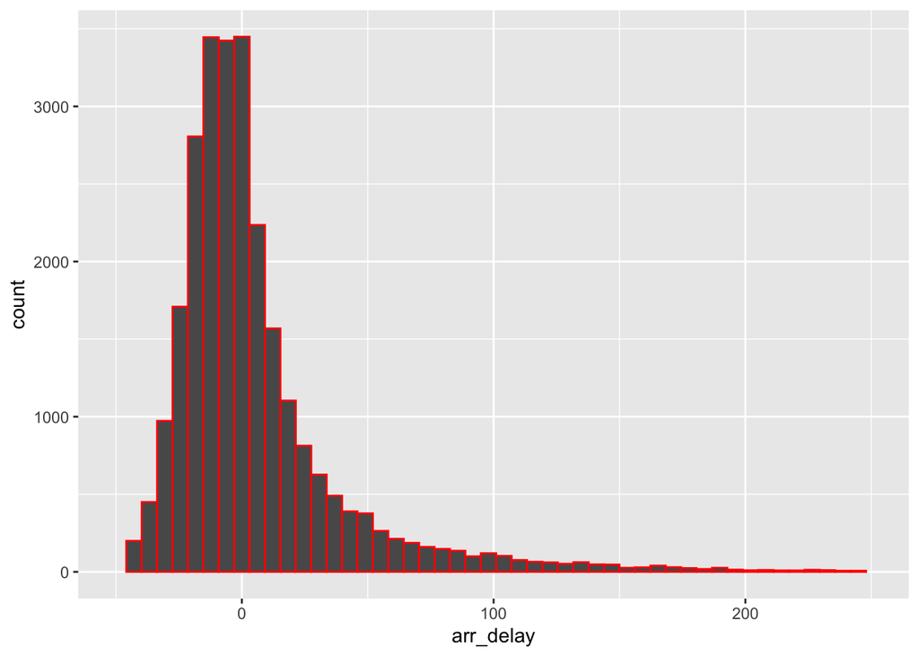

```r
flights %>%
  filter(month == "1" & year == "2013") %>%
  select(arr_delay) %>%
  ggplot() + geom_histogram(aes(x = arr_delay), color = "red", bins = 50, na.rm = TRUE) + xlim(-50, 250)
```

Since the mean is greater than the median, the data for arrival delays is skewed to the right.

### Airline Performance

Lets see if all airlines are equally terrible as far as flight arrival delays are concerned. For this question you will have to make sure that airline column is coded as a factor.

- Calculate average arrival delays by airline (Hint: look up the command `tapply`)

```r
# Using dplyr
carrier_delays_dplyr <- flights %>%
  group_by(carrier) %>%
  summarize(mean_delay = mean(arr_delay, na.rm = TRUE, .groups = "drop")) %>%
  arrange(desc(mean_delay))
# Using base R
carrier_delays_base <- tapply(flights$arr_delay, flights$carrier, mean, na.rm = TRUE)

carrier_delays_dplyr
```

```
## # A tibble: 16 x 2
##    carrier mean_delay
##    <fct>        <dbl>
##  1 F9          21.9
##  2 FL          20.1
##  3 EV          15.8
##  4 YV          15.6
##  5 OO          11.9
##  6 MQ          10.8
##  7 WN           9.65
##  8 B6           9.46
##  9 9E           7.38
## 10 UA           3.56
## 11 US           2.13
## 12 VX           1.76
## 13 DL           1.64
## 14 AA           0.364
## 15 HA          -6.92
## 16 AS          -9.93
```

```r
carrier_delays_base
```

```
##         9E         AA         AS         B6         DL         EV         F9
##  7.3796692  0.3642909 -9.9308886  9.4579733  1.6443409 15.7964311 21.9207048
##         FL         HA         MQ         OO         UA         US         VX
## 20.1159055 -6.9152047 10.7747334 11.9310345  3.5580111  2.1295951  1.7644644
##         WN         YV
##  9.6491199 15.5569853
```

- Draw a Bar Plot of Average Arrival Delays for all the Airlines (Hint: command for making a Bar Plot is simply `barplot`)

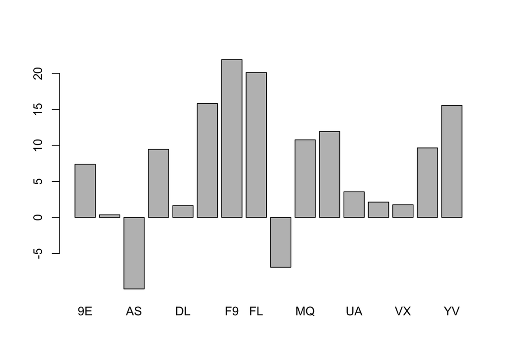

```r
# Base R
barplot(carrier_delays_base)
```

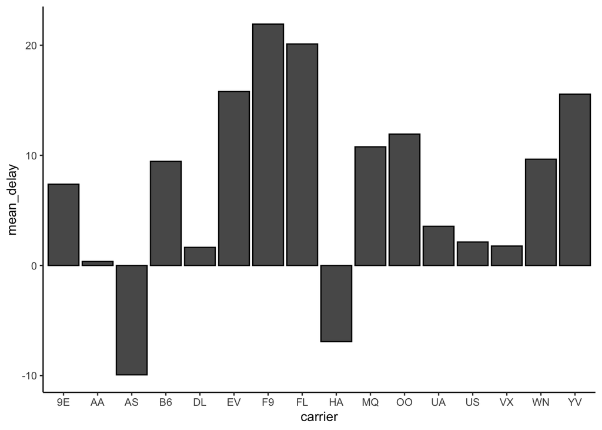

```r
# dplyr/ggplot
carrier_delays_dplyr %>% ggplot() + geom_col(aes(x = carrier, y = mean_delay), color = "black") + theme_classic()
```

- Which airline has the highest average arrival delay? Which airline has the smallest average arrival delay? Are there airlines that actually have negative average delay? Provide answer to this question in a text paragraph form using **inline R code**.

```r
#using dplyr
carrier_delays_dplyr %>% filter(mean_delay == max(mean_delay)) %>% select(carrier)
```

```
## # A tibble: 1 x 1
##   carrier
##   <fct>
## 1 F9
```

```r
carrier_delays_dplyr %>% filter(mean_delay == min(mean_delay)) %>% select(carrier)
```

```
## # A tibble: 1 x 1
##   carrier
##   <fct>
## 1 AS
```

```r
carrier_delays_dplyr %>% filter(mean_delay < 0) %>% select(carrier)
```

```
## # A tibble: 2 x 1
##   carrier
##   <fct>
## 1 HA
## 2 AS
```

```r
carrier_delays_dplyr$carrier[carrier_delays_dplyr$mean_delay == max(carrier_delays_dplyr$mean_delay)]
```

```
## [1] F9
## Levels: 9E AA AS B6 DL EV F9 FL HA MQ OO UA US VX WN YV
```

```r
#using base R
names(carrier_delays_base[carrier_delays_base == max(carrier_delays_base)])
```

```
## [1] "F9"
```

```r
names(carrier_delays_base[carrier_delays_base == min(carrier_delays_base)])
```

```
## [1] "AS"
```

```r
names(carrier_delays_base[carrier_delays_base < 0])
```

```
## [1] "AS" "HA"
```

F9 has the highest average arrival delay. AS has the lowest average arrival delay. AS, HA have negative average arrival delays, so yes airlines have negative average delays.

### Air Gain

Create a new column named airgain such that airgain = (departure delay - arrival delay) : this is the amount of delay a flight made up while in air.

```r
flights <- flights %>% mutate(airgain = dep_delay - arr_delay)
```

1. Explore airgain data - calculate suitable descriptive statistics and appropriate graphics to better understand this data. This part is open ended - you do what you feel works best for you.

```r
min(flights$airgain, na.rm = TRUE)
```

```
## [1] -196
```

```r
max(flights$airgain, na.rm = TRUE)
```

```
## [1] 109
```

```r
mean(flights$airgain, na.rm = TRUE)
```

```
## [1] 5.659779
```

```r
median(flights$airgain, na.rm = TRUE)
```

```
## [1] 7
```

```r
summary(flights$airgain)
```

```
##    Min. 1st Qu.  Median    Mean 3rd Qu.    Max.    NA's
## -196.00   -3.00    7.00    5.66   17.00  109.00    9430
```

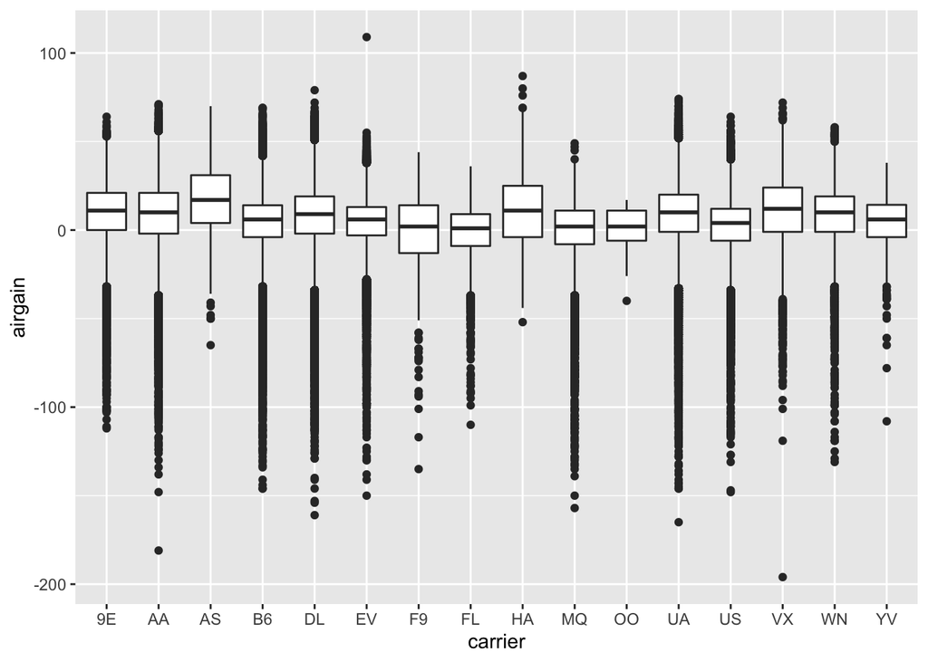

```r
flights %>% ggplot() + geom_boxplot(aes(x = carrier, y = airgain))
```

2. Answer the questions:
- do airlines actually gain any time when in air on average?

```r
mean(flights$airgain, na.rm = TRUE)
```

```
## [1] 5.659779
```

Yes, airlines actually gain `5.6597789` time when in air on average.

- Calculate average airgain for different airlines - which airlines do a better job, which do a worse job?

```r
flights %>%
  group_by(carrier) %>%
  summarize(mean_gain = mean(airgain, na.rm = TRUE)) %>%
  arrange(desc(mean_gain))
```

```
## # A tibble: 16 x 2
##    carrier mean_gain
##    <fct>       <dbl>
##  1 AS         15.8
##  2 HA         11.8
##  3 VX         11.0
##  4 9E          9.06
##  5 UA          8.46
##  6 AA          8.20
##  7 WN          8.01
##  8 DL          7.58
##  9 EV          4.04
## 10 B6          3.51
## 11 YV          3.34
## 12 US          1.62
## 13 OO          0.655
## 14 MQ         -0.329
## 15 FL         -1.51
## 16 F9         -1.72
```

From the dataframe, we can see that carrier AS does the best job, gaining 15.76 mins of airtime on average, while F9 does the worst, losing 1.72 mins of airtime on average.

Assuming a “better job” is gaining more than 10 minutes of airtimes, carriers AS, HA, and VX do a better job. Conversely, if a worse job is losing airtime, carriers MQ, FL, and F9 do a worse job.

### Merging Data Frames

> This section and the next is new compared to the class exercise. As you had an opportunity to work together in your breakout rooms for previous questions, this and the next section will carry a higher weight in grading for this HW.

You can get detailed information about the physical planes in our dataset in this file: `planes.csv`. Download and save this file in your project directory.

1. Read the `planes.csv` file using `read.csv` command. Do any data cleaning necessary.

```r
planes <- read.csv("planes.csv")
```

```r
planes$X <- NULL
planes$tailnum <- factor(planes$tailnum)
planes$type <- factor(planes$type)
planes$manufacturer <- factor(planes$manufacturer)
planes$model <- factor(planes$model)
planes$engine <- factor(planes$engine)
planes$year <- factor(planes$year)

str(planes)
```

```
## 'data.frame':    3322 obs. of  9 variables:
##  $ tailnum     : Factor w/ 3322 levels "N10156","N102UW",..: 1 2 3 4 5 6 7 8 9 10 ...
##  $ year        : Factor w/ 46 levels "1956","1959",..: 37 31 32 32 35 32 32 32 32 32 ...
##  $ type        : Factor w/ 3 levels "Fixed wing multi engine",..: 1 1 1 1 1 1 1 1 1 1 ...
##  $ manufacturer: Factor w/ 35 levels "AGUSTA SPA","AIRBUS",..: 18 3 3 3 18 3 3 3 3 3 ...
##  $ model       : Factor w/ 127 levels "150","172E","172M",..: 108 87 87 87 107 87 87 87 87 87 ...
##  $ engines     : int  2 2 2 2 2 2 2 2 2 2 ...
##  $ seats       : int  55 182 182 182 55 182 182 182 182 182 ...
##  $ speed       : int  NA NA NA NA NA NA NA NA NA NA ...
##  $ engine      : Factor w/ 6 levels "4 Cycle","Reciprocating",..: 3 3 3 3 3 3 3 3 3 3 ...
```

2. Merge the flights data and the planes data using the `merge` command. You should do the merge on the common column named `tailnum`. *getting this right may need some trial and error and getting some help*.

```r
merge_df <- merge(flights, planes, sort = FALSE, by = "tailnum")
merge_df$X <- NULL
```

3. Now that you have a merged dataset, think of what interesting questions that you can ask that can be answered using the merged dataset. You are asked to pose five interesting questions and answer them. (For example: who are the top 10 manufacturers of planes that fly out of NYC airports?) **Be creative. Be bold. Ask questions that you would want to know answers to even if you were not doing this for a HW.**

Q1: How does average arrival delay vary by engine type?

```r
merge_df$engine <- factor(merge_df$engine)

q1df <- merge_df %>%
  group_by(engine) %>%
  summarize(mean_arr_delay = mean(arr_delay, na.rm = TRUE), .groups = "keep") %>%
  arrange(desc(mean_arr_delay))
q1df
```

```
## # A tibble: 6 x 2
## # Groups:   engine [6]
##   engine        mean_arr_delay
##   <fct>                  <dbl>
## 1 4 Cycle                 9.72
## 2 Turbo-shaft             9.28
## 3 Turbo-fan               7.72
## 4 Reciprocating           5.72
## 5 Turbo-prop              4.89
## 6 Turbo-jet               3.19
```

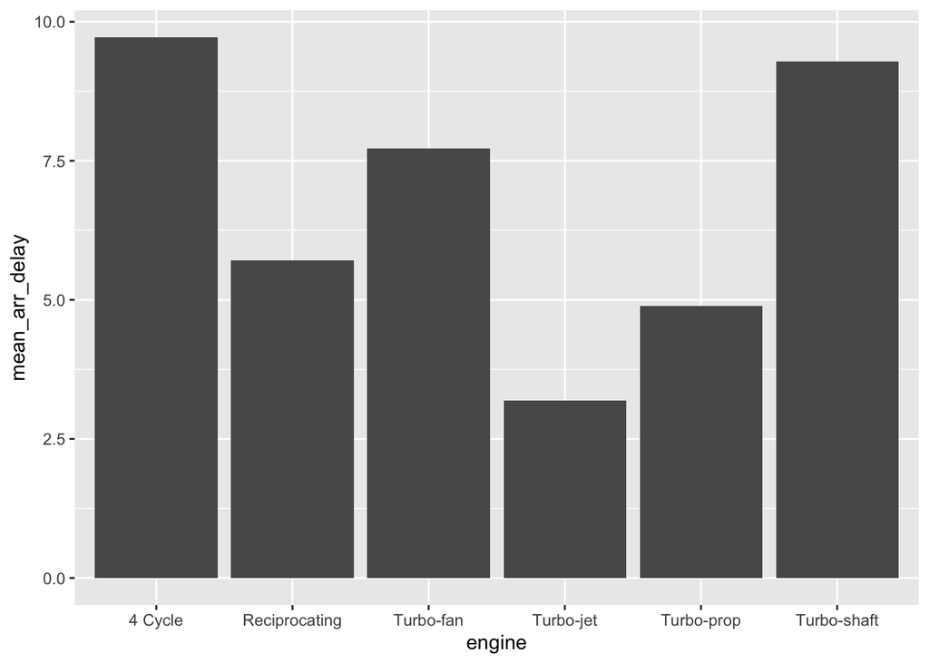

```r
q1df %>% ggplot() + geom_col(aes(x = engine, y = mean_arr_delay), na.rm = TRUE)
```

Based on the tabular output and bar chart, it is clear that 4 Cycle engines have the highest average arrival delay and Turbo-jet engines have the lowest average arrival delay. Furthermore, the average arrival delay for 4 Cycle engines is more than 3 times greater than that of Turbo-jets.

Q2: How do the amount of flights vary by month for the top 2 manufacturers?

```r
#find top 2 manufacturers
merge_df %>% group_by(manufacturer) %>% summarize(count = n(), .groups = "drop") %>% arrange(desc(count)) %>% slice(1:2)
```

```
## # A tibble: 2 x 2
##   manufacturer count
##   <fct>        <int>
## 1 BOEING       82912
## 2 EMBRAER      66068
```

```r
#table output
merge_df %>%
  filter(manufacturer == c("BOEING", "EMBRAER")) %>%
  group_by(manufacturer, year.x, month) %>%
  summarize(flights = n(), .groups = "drop")
```

```
## # A tibble: 24 x 4
##    manufacturer year.x month flights
##    <fct>         <int> <fct>   <int>
##  1 BOEING         2013 1        3337
##  2 BOEING         2013 2        3014
##  3 BOEING         2013 3        3719
##  4 BOEING         2013 4        3565
##  5 BOEING         2013 5        3562
##  6 BOEING         2013 6        3522
##  7 BOEING         2013 7        3726
##  8 BOEING         2013 8        3870
##  9 BOEING         2013 9        3206
## 10 BOEING         2013 10       3292
## # … with 14 more rows
```

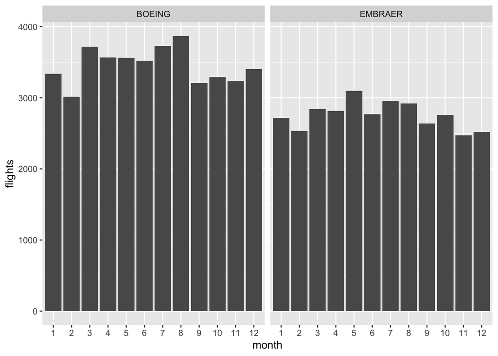

```r
#visualization
merge_df %>%
  filter(manufacturer == c("BOEING", "EMBRAER")) %>%
  group_by(manufacturer, year.x, month) %>%
  summarize(flights = n(), .groups = "drop") %>%
  ggplot() +
  geom_col(aes(x = month, y = flights)) + facet_grid(~ manufacturer)
```

Q3: How does average arrival and departure delays vary by number of seats and does a correlation exist between seats and delays?

```r
merge_df %>%
  group_by(seats) %>%
  summarize(avg_arr_delay = mean(arr_delay, na.rm = TRUE), avg_dep_delay = mean(dep_delay, na.rm = TRUE), .groups = "drop") %>%
  arrange(desc(avg_arr_delay))
```

```
## # A tibble: 48 x 3
##    seats avg_arr_delay avg_dep_delay
##    <int>         <dbl>         <dbl>
##  1   450         120           132
##  2   147          33.5          42.6
##  3   375          29.8          19.7
##  4   300          24.2          26.9
##  5   100          17.9          18.0
##  6   400          17.8          21.3
##  7    55          15.9          19.2
##  8    11          12.3          15.7
##  9   275          11.9          16.3
## 10     6          10.7          11.6
## # … with 38 more rows
```

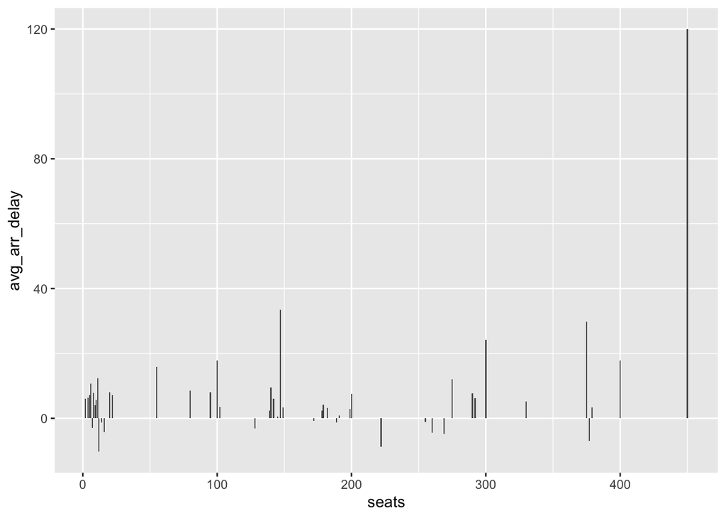

```r
merge_df %>%
  group_by(seats) %>%
  summarize(avg_arr_delay = mean(arr_delay, na.rm = TRUE), avg_dep_delay = mean(dep_delay, na.rm = TRUE), .groups = "drop") %>%
  ggplot() + geom_col(aes(x = seats, y = avg_arr_delay))
```

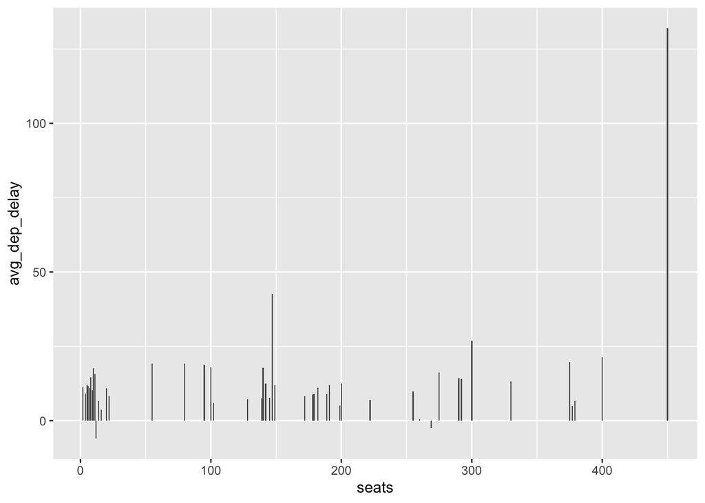

```r
merge_df %>%
  group_by(seats) %>%
  summarize(avg_arr_delay = mean(arr_delay, na.rm = TRUE), avg_dep_delay = mean(dep_delay, na.rm = TRUE), .groups = "drop") %>%
  ggplot() + geom_col(aes(x = seats, y = avg_dep_delay))
```

```r
cor(merge_df$seats, merge_df$arr_delay, use = "complete.obs")
```

```
## [1] -0.0724627
```

```r
cor(merge_df$seats, merge_df$dep_delay, use = "complete.obs")
```

```
## [1] -0.05463222
```

Based on the output table and charts, no significant relationship seems to exist between the number of seats and average departure delay or average arrival delay. This was validated by finding the correlation coefficients between seats and each delay, which showed that both delay types had near-zero correlations with the number of seats.

Q4: We know arrival delay and departure delay are not correlated with the number of seats: Are arrival delay and departure delay correlated with each other overall and does this change by plane type?

```r
#overall correlation
cor(merge_df$arr_delay, merge_df$dep_delay, use = "complete.obs")
```

```
## [1] 0.9168737
```

```r
#correlation by airport
merge_df %>%
  group_by(type) %>%
  summarize(correlation = cor(arr_delay, dep_delay, use = "complete.obs"))
```

```
## # A tibble: 3 x 2
##   type                     correlation
##   <fct>                          <dbl>
## 1 Fixed wing multi engine        0.917
## 2 Fixed wing single engine       0.902
## 3 Rotorcraft                     0.911
```

Q5: What manufacturer had the most air time and from which origin airport did the most air time come from?

```r
#find manufacturer with the most air time
merge_df %>%
  group_by(manufacturer) %>%
  summarize(total_air_time = sum(air_time, na.rm = TRUE), .groups = "drop") %>%
  arrange(desc(total_air_time)) %>%
  slice(1)
```

```
## # A tibble: 1 x 2
##   manufacturer total_air_time
##   <fct>                 <int>
## 1 BOEING             17767056
```

```r
merge_df %>%
  filter(manufacturer == "BOEING") %>%
  group_by(manufacturer, origin) %>%
  summarize(total_air_time = sum(air_time, na.rm = TRUE), .groups = "drop") %>%
  slice(1)
```

```
## # A tibble: 1 x 3
##   manufacturer origin total_air_time
##   <fct>        <fct>           <int>
## 1 BOEING       EWR           8444440
```

### Making Your HTML Look Nice

We want our report to be good looking, professional documents. To that end, I am asking you to do the following:

- Have a floating table of contents
- Include code folding in your output. You can find more about code folding here: https://bookdown.org/yihui/rmarkdown/html-document.html#code-folding

That’s it. Once you are done, make sure everything works and knits well and then you can push your changes to the GitHub repo and uplaod the RMD flile and the html output to Canvas.

**Have Fun!**

Sanjeev